# 📖 Bitcoin Hourly Data — Storytelling complet

- Show All Code
- Hide All Code
- View Source

Author

Analyse technique & visualisation

Published

January 7, 2026

# Introduction

Ce document présente un storytelling complet des données Bitcoin horaires (`btc_hourly_ohclv_ta.csv`) à travers 7 actes : contexte, volatilité, volume, momentum, tendances, ratios et synthèse.

## Setup : Packages & données

```r
options(repos = c(CRAN = "https://cloud.r-project.org"))

# Packages nécessaires
pkgs <- c("tidyverse", "lubridate", "TTR", "zoo", "patchwork", "DT", "scales", "knitr")
missing <- setdiff(pkgs, rownames(installed.packages()))
if (length(missing) > 0) install.packages(missing)

suppressPackageStartupMessages({
  library(tidyverse)
  library(lubridate)
  library(TTR)
  library(zoo)
  library(patchwork)
  library(DT)
  library(scales)
  library(knitr)
})

knitr::opts_chunk$set(
  fig.width = 10,
  fig.height = 6,
  dpi = 150
)
```

```r
# Lecture CSV
csv_path <- "btc_hourly_ohclv_ta.csv"
stopifnot(file.exists(csv_path))

df <- read_csv(csv_path, show_col_types = FALSE)

cat("Dataset chargé :", nrow(df), "lignes,", ncol(df), "colonnes\n")
```

```
Dataset chargé : 95925 lignes, 28 colonnes
```

## Prétraitement

```r
# Trouver les colonnes clés (insensible à la casse)
cn <- names(df)
cn_lc <- tolower(cn)
find_col <- function(cands) {
  i <- which(cn_lc %in% tolower(cands))
  if (length(i) == 0) return(NA_integer_)
  i[1]
}

idx_time   <- find_col(c("datetime","date","timestamp","time","open_time","close_time"))
idx_open   <- find_col(c("open"))
idx_high   <- find_col(c("high"))
idx_low    <- find_col(c("low"))
idx_close  <- find_col(c("close","close_price","closing_price"))
idx_volume <- find_col(c("volume","vol","quote_volume"))

dt <- as_tibble(df)
if (!is.na(idx_time)) {
  time_raw <- df[[idx_time]]
  if (!inherits(time_raw, "POSIXct")) {
    tt <- suppressWarnings(lubridate::ymd_hms(time_raw, tz = "UTC"))
    if (all(is.na(tt))) tt <- suppressWarnings(lubridate::ymd_hm(time_raw, tz = "UTC"))
    if (all(is.na(tt))) tt <- suppressWarnings(lubridate::parse_date_time(time_raw, orders = c("Ymd HMS","Ymd HM","Y-m-d H:M:S","dmy HMS","dmy HM","ymd"), tz = "UTC"))
    time_parsed <- tt
  } else {
    time_parsed <- time_raw
  }
  dt <- dt %>% mutate(datetime = time_parsed)
}
if (!is.na(idx_open))   dt <- dt %>% mutate(open  = suppressWarnings(as.numeric(df[[idx_open]])))
if (!is.na(idx_high))   dt <- dt %>% mutate(high  = suppressWarnings(as.numeric(df[[idx_high]])))
if (!is.na(idx_low))    dt <- dt %>% mutate(low   = suppressWarnings(as.numeric(df[[idx_low]])))
if (!is.na(idx_close))  dt <- dt %>% mutate(close = suppressWarnings(as.numeric(df[[idx_close]])))
if (!is.na(idx_volume)) dt <- dt %>% mutate(volume = suppressWarnings(as.numeric(df[[idx_volume]])))

if ("datetime" %in% names(dt)) dt <- dt %>% arrange(datetime)

# Fenêtres
window_short <- 20L
window_fast  <- 12L
window_slow  <- 26L
window_sig   <- 9L
window_vol30d <- 720L  # 30j * 24h

# Returns (PRICE_CHANGE)
if ("close" %in% names(dt)) {
  dt <- dt %>% mutate(PRICE_CHANGE = close/lag(close) - 1)
}

# ATR (n=14)
if (all(c("high","low","close") %in% names(dt))) {
  atr_df <- TTR::ATR(cbind(dt$high, dt$low, dt$close), n = 14)
  dt$ATR <- as.numeric(atr_df[,"atr"])
}

# RSI (n=14)
if ("close" %in% names(dt)) {
  dt$RSI <- as.numeric(TTR::RSI(dt$close, n = 14))
}

# SMA/EMA, MACD
if ("close" %in% names(dt)) {
  dt$SMA_20 <- as.numeric(TTR::SMA(dt$close, n = window_short))
  dt$EMA_12 <- as.numeric(TTR::EMA(dt$close, n = window_fast))
  dt$EMA_26 <- as.numeric(TTR::EMA(dt$close, n = window_slow))
  macd <- TTR::MACD(dt$close, nFast = window_fast, nSlow = window_slow, nSig = window_sig)
  dt$MACD <- as.numeric(macd[ ,"macd"])
  dt$MACD_SIGNAL <- as.numeric(macd[ ,"signal"])
}

# Rolling volatility 30 jours
if ("PRICE_CHANGE" %in% names(dt)) {
  dt$VOLATILITY_30D <- as.numeric(zoo::rollapply(dt$PRICE_CHANGE, width = window_vol30d, FUN = sd, align = "right", fill = NA, na.rm = TRUE))
  dt$PRICE_VOLATILITY_30D <- dt$VOLATILITY_30D
}

# VOLUME_SMA
if ("volume" %in% names(dt)) {
  dt$VOLUME_SMA <- as.numeric(TTR::SMA(dt$volume, n = window_short))
}

# Ratios
if (all(c("high","low","close") %in% names(dt))) {
  dt$HIGH_LOW_RATIO <- (dt$high - dt$low) / dt$close
}
if (all(c("close","open") %in% names(dt))) {
  dt$CLOSE_OPEN_RATIO <- dt$close/dt$open - 1
}

# Stochastique
if (all(c("high","low","close") %in% names(dt))) {
  st <- suppressWarnings(TTR::stoch(cbind(dt$high, dt$low, dt$close)))
  if (!is.null(st)) {
    dt$STOCH_K <- as.numeric(st[,"fastK"]) * 100
    dt$STOCH_D <- as.numeric(st[,"fastD"]) * 100
  }
}

cat("Prétraitement terminé.\n")
```

```
Prétraitement terminé.
```

# 🎬 Acte 1 — Le contexte : “Une décennie de Bitcoin”

**Message:** Bitcoin est passé d’un actif marginal à un marché hautement volatil et liquide.

## Statistiques globales

```r
stopifnot(all(c("datetime","close") %in% names(dt)))

rng <- range(dt$datetime, na.rm = TRUE)
n_hours <- sum(!is.na(dt$datetime))
price_min <- min(dt$close, na.rm = TRUE)
price_median <- median(dt$close, na.rm = TRUE)
price_max <- max(dt$close, na.rm = TRUE)
vol_total <- if ("volume" %in% names(dt)) sum(dt$volume, na.rm = TRUE) else NA_real_

tibble(
  Métrique = c("Période début", "Période fin", "Heures totales", "Prix min", "Prix médian", "Prix max", "Volume total"),
  Valeur = c(
    format(rng[1]),
    format(rng[2]),
    prettyNum(n_hours, big.mark = " "),
    prettyNum(round(price_min, 2), big.mark = " "),
    prettyNum(round(price_median, 2), big.mark = " "),
    prettyNum(round(price_max, 2), big.mark = " "),
    if (!is.na(vol_total)) prettyNum(round(vol_total, 0), big.mark = " ") else "N/A"
  )
) %>% kable()
```

| Métrique | Valeur |
| --- | --- |
| Période début | 2014-12-15 06:00:00 |
| Période fin | 2025-11-23 |
| Heures totales | 95 925 |
| Prix min | 165.07 |
| Prix médian | 10 968.3 |
| Prix max | 126 113.7 |
| Volume total | 3.749662e+12 |

## Visualisations

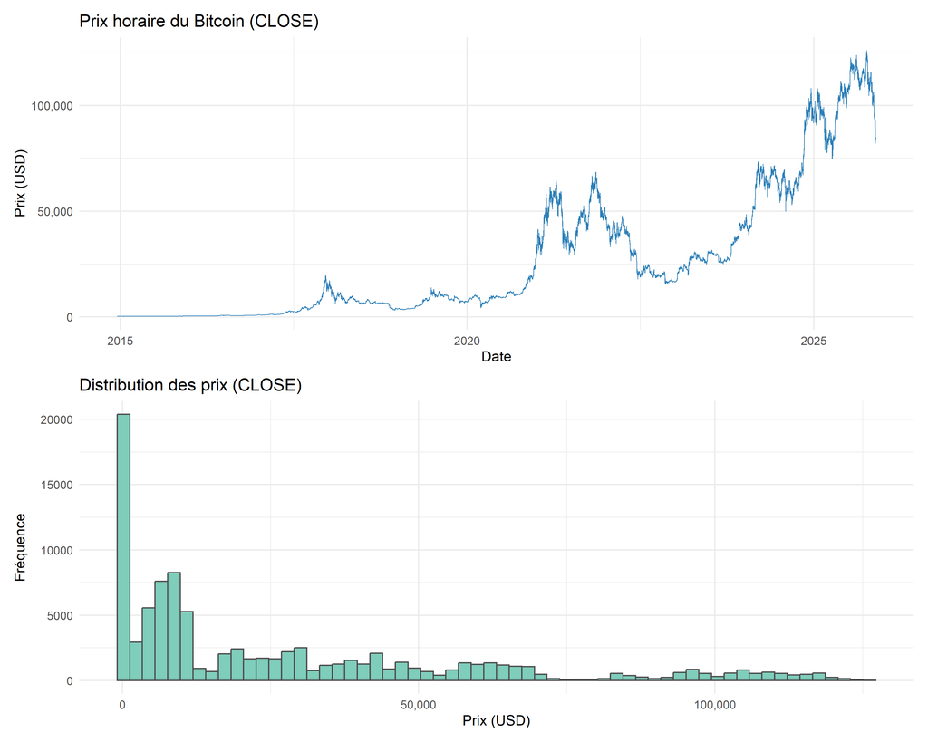

```r
p1 <- ggplot(dt, aes(x = datetime, y = close)) +
  geom_line(color = "#2C7FB8", linewidth = 0.3) +
  scale_y_continuous(labels = scales::comma) +
  labs(title = "Prix horaire du Bitcoin (CLOSE)", x = "Date", y = "Prix (USD)") +
  theme_minimal()

p2 <- ggplot(dt, aes(x = close)) +
  geom_histogram(bins = 60, fill = "#7FCDBB", color = "grey30") +
  scale_x_continuous(labels = scales::comma) +
  labs(title = "Distribution des prix (CLOSE)", x = "Prix (USD)", y = "Fréquence") +
  theme_minimal()

p1 / p2
```

**Conclusion:** La croissance n’est pas linéaire → phases d’explosion et de stagnation.

# 🎬 Acte 2 — La volatilité : l’ADN du Bitcoin

**Message:** La volatilité est une constante, mais son intensité change selon les périodes.

## Statistiques

```r
stats_vol <- list()

if ("ATR" %in% names(dt)) {
  stats_vol$ATR_moyen <- mean(dt$ATR, na.rm = TRUE)
  stats_vol$ATR_max <- max(dt$ATR, na.rm = TRUE)
}

if ("VOLATILITY_30D" %in% names(dt)) {
  stats_vol$VOL30D_moyen <- mean(dt$VOLATILITY_30D, na.rm = TRUE)
  stats_vol$VOL30D_max <- max(dt$VOLATILITY_30D, na.rm = TRUE)

  if ("datetime" %in% names(dt)) {
    dt_clean <- dt %>% filter(!is.na(VOLATILITY_30D), !is.na(datetime))
    mid_date <- median(dt_clean$datetime, na.rm = TRUE)
    early <- dt_clean %>% filter(datetime < mid_date)
    recent <- dt_clean %>% filter(datetime >= mid_date)
    stats_vol$VOL_early <- mean(early$VOLATILITY_30D, na.rm = TRUE)
    stats_vol$VOL_recent <- mean(recent$VOLATILITY_30D, na.rm = TRUE)
  }
}

as_tibble(stats_vol) %>%
  pivot_longer(everything(), names_to = "Métrique", values_to = "Valeur") %>%
  mutate(Valeur = signif(Valeur, 4)) %>%
  kable()
```

| Métrique | Valeur |
| --- | --- |
| ATR_moyen | 2.039e+02 |
| ATR_max | 2.166e+03 |
| VOL30D_moyen | 6.807e-03 |
| VOL30D_max | 2.000e-02 |
| VOL_early | 7.643e-03 |
| VOL_recent | 5.971e-03 |

## Visualisations

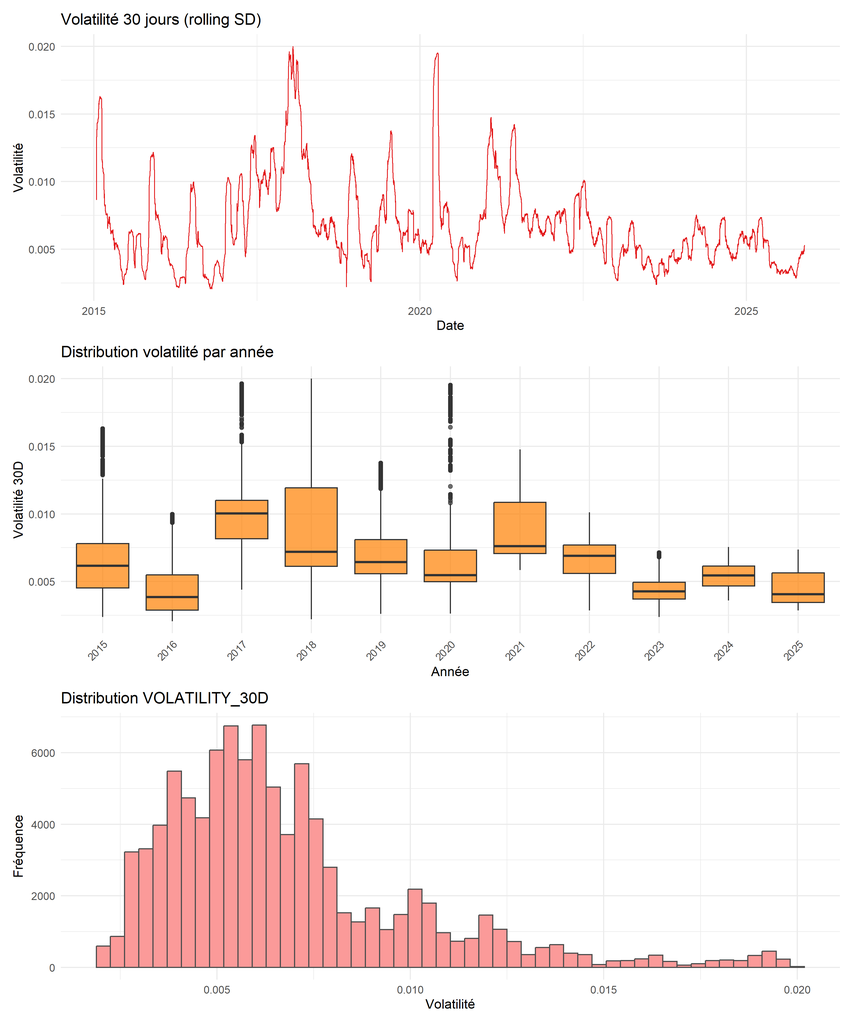

```r
plots <- list()

if ("VOLATILITY_30D" %in% names(dt) && "datetime" %in% names(dt)) {
  dt_clean <- dt %>% filter(!is.na(VOLATILITY_30D), !is.na(datetime))

  plots$p1 <- ggplot(dt_clean, aes(x = datetime, y = VOLATILITY_30D)) +
    geom_line(color = "#E31A1C", linewidth = 0.4) +
    labs(title = "Volatilité 30 jours (rolling SD)", x = "Date", y = "Volatilité") +
    theme_minimal()

  dt_clean <- dt_clean %>% mutate(year = lubridate::year(datetime))
  plots$p2 <- ggplot(dt_clean, aes(x = factor(year), y = VOLATILITY_30D)) +
    geom_boxplot(fill = "#FF7F00", alpha = 0.7) +
    labs(title = "Distribution volatilité par année", x = "Année", y = "Volatilité 30D") +
    theme_minimal() +
    theme(axis.text.x = element_text(angle = 45, hjust = 1))

  plots$p3 <- ggplot(dt_clean, aes(x = VOLATILITY_30D)) +
    geom_histogram(bins = 50, fill = "#FB9A99", color = "grey30") +
    labs(title = "Distribution VOLATILITY_30D", x = "Volatilité", y = "Fréquence") +
    theme_minimal()

  wrap_plots(plots, ncol = 1)
}
```

**Conclusion:** Le marché mûrit, mais reste instable → opportunité & risque.

# 🎬 Acte 3 — Le volume : quand le marché s’emballe

**Message:** Le volume raconte l’histoire des crises et des bull runs.

## Statistiques

```r
if ("volume" %in% names(dt)) {
  vol_stats <- tibble(
    Métrique = c("Volume moyen", "Volume médian", "Top 1% (quantile 99%)"),
    Valeur = c(
      prettyNum(round(mean(dt$volume, na.rm = TRUE), 0), big.mark = " "),
      prettyNum(round(median(dt$volume, na.rm = TRUE), 0), big.mark = " "),
      prettyNum(round(quantile(dt$volume, 0.99, na.rm = TRUE), 0), big.mark = " ")
    )
  )

  if ("PRICE_CHANGE" %in% names(dt)) {
    dt_clean <- dt %>% filter(!is.na(volume), !is.na(PRICE_CHANGE))
    if (nrow(dt_clean) > 2) {
      corr <- cor(dt_clean$volume, abs(dt_clean$PRICE_CHANGE), use = "complete.obs")
      vol_stats <- vol_stats %>% add_row(
        Métrique = "Corrélation VOLUME ↔ |PRICE_CHANGE|",
        Valeur = as.character(signif(corr, 3))
      )
    }
  }

  vol_stats %>% kable()
}
```

| Métrique | Valeur |
| --- | --- |
| Volume moyen | 39 089 515 |
| Volume médian | 15 739 797 |
| Top 1% (quantile 99%) | 337 754 550 |
| Corrélation VOLUME ↔︎ \|PRICE_CHANGE\| | 0.253 |

## Visualisations

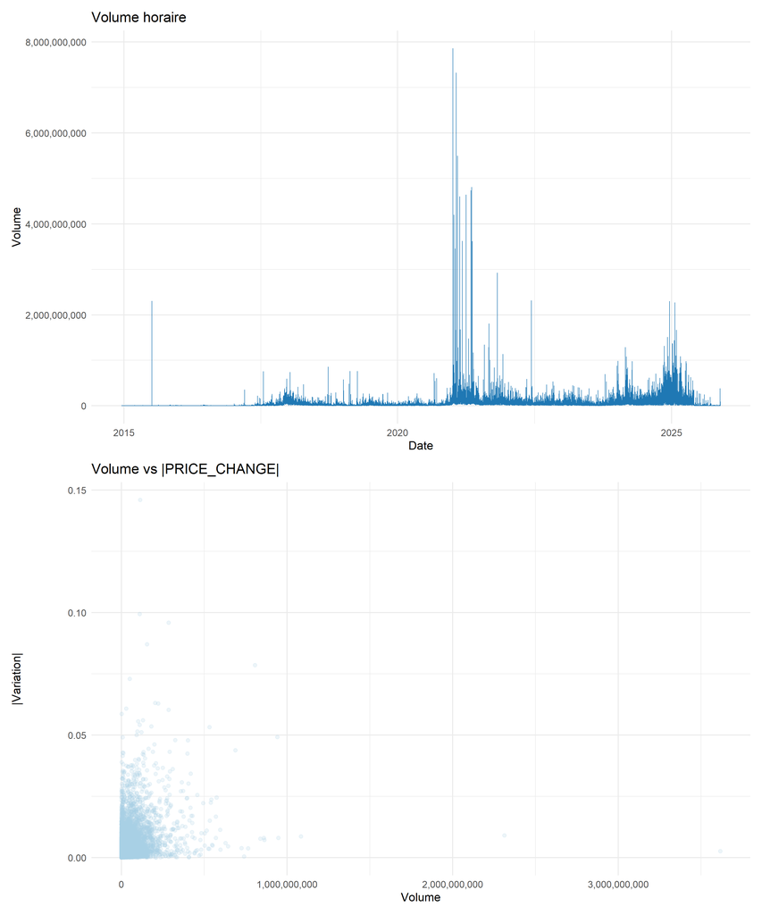

```r
if ("volume" %in% names(dt) && "datetime" %in% names(dt)) {
  dt_clean <- dt %>% filter(!is.na(volume), !is.na(datetime))

  p1 <- ggplot(dt_clean, aes(x = datetime, y = volume)) +
    geom_line(color = "#1F78B4", linewidth = 0.3) +
    scale_y_continuous(labels = scales::comma) +
    labs(title = "Volume horaire", x = "Date", y = "Volume") +
    theme_minimal()

  p2 <- NULL
  if ("PRICE_CHANGE" %in% names(dt)) {
    dt_clean2 <- dt_clean %>% filter(!is.na(PRICE_CHANGE)) %>%
      mutate(abs_change = abs(PRICE_CHANGE))
    p2 <- ggplot(dt_clean2 %>% sample_n(min(10000, nrow(dt_clean2))),
                 aes(x = volume, y = abs_change)) +
      geom_point(alpha = 0.2, color = "#A6CEE3") +
      scale_x_continuous(labels = scales::comma) +
      labs(title = "Volume vs |PRICE_CHANGE|", x = "Volume", y = "|Variation|") +
      theme_minimal()
  }

  if (!is.null(p2)) {
    p1 / p2
  } else {
    p1
  }
}
```

# 🎬 Acte 4 — Momentum & psychologie

**Message:** Les indicateurs traduisent les émotions du marché.

## Statistiques

```r
if ("RSI" %in% names(dt)) {
  tibble(
    Métrique = c("RSI moyen", "% temps RSI > 70 (surachat)", "% temps RSI < 30 (survente)"),
    Valeur = c(
      signif(mean(dt$RSI, na.rm = TRUE), 4),
      paste0(signif(mean(dt$RSI > 70, na.rm = TRUE) * 100, 3), "%"),
      paste0(signif(mean(dt$RSI < 30, na.rm = TRUE) * 100, 3), "%")
    )
  ) %>% kable()
}
```

| Métrique | Valeur |
| --- | --- |
| RSI moyen | 51.1 |
| % temps RSI > 70 (surachat) | 6.42% |
| % temps RSI < 30 (survente) | 4.64% |

## Visualisations

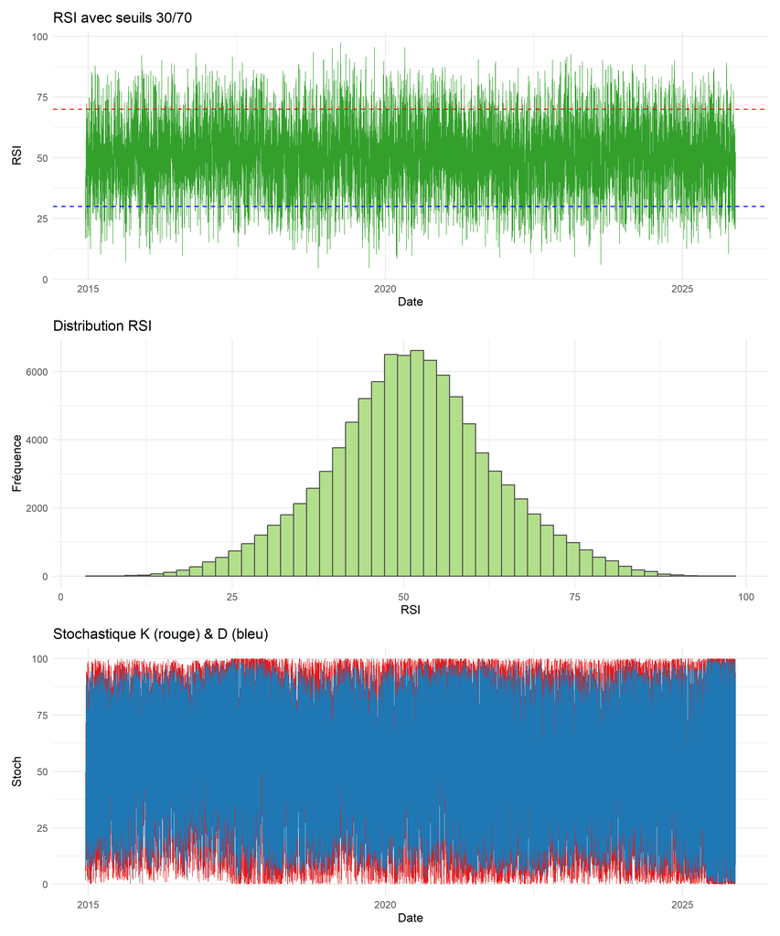

```r
plots <- list()

if ("RSI" %in% names(dt) && "datetime" %in% names(dt)) {
  dt_clean <- dt %>% filter(!is.na(RSI), !is.na(datetime))

  plots$p1 <- ggplot(dt_clean, aes(x = datetime, y = RSI)) +
    geom_line(color = "#33A02C", linewidth = 0.3) +
    geom_hline(yintercept = 70, color = "red", linetype = "dashed") +
    geom_hline(yintercept = 30, color = "blue", linetype = "dashed") +
    labs(title = "RSI avec seuils 30/70", x = "Date", y = "RSI") +
    theme_minimal()

  plots$p2 <- ggplot(dt_clean, aes(x = RSI)) +
    geom_histogram(bins = 50, fill = "#B2DF8A", color = "grey30") +
    labs(title = "Distribution RSI", x = "RSI", y = "Fréquence") +
    theme_minimal()
}

if (all(c("STOCH_K","STOCH_D","datetime") %in% names(dt))) {
  dt_clean <- dt %>% filter(!is.na(STOCH_K), !is.na(STOCH_D), !is.na(datetime))
  plots$p3 <- ggplot(dt_clean, aes(x = datetime)) +
    geom_line(aes(y = STOCH_K), color = "#E31A1C", linewidth = 0.3) +
    geom_line(aes(y = STOCH_D), color = "#1F78B4", linewidth = 0.3) +
    labs(title = "Stochastique K (rouge) & D (bleu)", x = "Date", y = "Stoch") +
    theme_minimal()
}

if (length(plots) > 0) wrap_plots(plots, ncol = 1)
```

**Conclusion:** Le marché passe plus de temps en zone extrême qu’on ne l’imagine.

# 🎬 Acte 5 — Tendances & régimes

**Message:** Bitcoin alterne entre tendance et range.

## Statistiques

```r
stats_list <- list()

if (all(c("close","SMA_20") %in% names(dt))) {
  dt_clean <- dt %>% filter(!is.na(close), !is.na(SMA_20))
  stats_list$pct_above_sma <- paste0(signif(mean(dt_clean$close > dt_clean$SMA_20) * 100, 3), "%")
}

if (all(c("EMA_12","EMA_26") %in% names(dt))) {
  dt_clean <- dt %>% filter(!is.na(EMA_12), !is.na(EMA_26))
  stats_list$pct_ema_cross <- paste0(signif(mean(dt_clean$EMA_12 > dt_clean$EMA_26) * 100, 3), "%")
}

if (length(stats_list) > 0) {
  tibble(
    Métrique = c("% temps CLOSE > SMA_20", "% temps EMA_12 > EMA_26"),
    Valeur = unlist(stats_list)
  ) %>% kable()
}
```

| Métrique | Valeur |
| --- | --- |
| % temps CLOSE > SMA_20 | 53.1% |
| % temps EMA_12 > EMA_26 | 54% |

## Visualisations

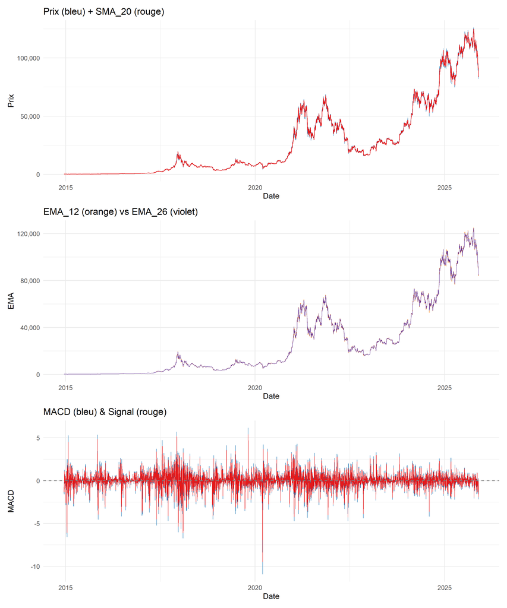

```r
plots <- list()

if (all(c("close","SMA_20","datetime") %in% names(dt))) {
  dt_clean <- dt %>% filter(!is.na(close), !is.na(SMA_20), !is.na(datetime))
  plots$p1 <- ggplot(dt_clean, aes(x = datetime)) +
    geom_line(aes(y = close), color = "#2C7FB8", linewidth = 0.3) +
    geom_line(aes(y = SMA_20), color = "#E31A1C", linewidth = 0.4) +
    scale_y_continuous(labels = scales::comma) +
    labs(title = "Prix (bleu) + SMA_20 (rouge)", x = "Date", y = "Prix") +
    theme_minimal()
}

if (all(c("EMA_12","EMA_26","datetime") %in% names(dt))) {
  dt_clean <- dt %>% filter(!is.na(EMA_12), !is.na(EMA_26), !is.na(datetime))
  plots$p2 <- ggplot(dt_clean, aes(x = datetime)) +
    geom_line(aes(y = EMA_12), color = "#FF7F00", linewidth = 0.3) +
    geom_line(aes(y = EMA_26), color = "#6A3D9A", linewidth = 0.3) +
    scale_y_continuous(labels = scales::comma) +
    labs(title = "EMA_12 (orange) vs EMA_26 (violet)", x = "Date", y = "EMA") +
    theme_minimal()
}

if (all(c("MACD","MACD_SIGNAL","datetime") %in% names(dt))) {
  dt_clean <- dt %>% filter(!is.na(MACD), !is.na(MACD_SIGNAL), !is.na(datetime))
  plots$p3 <- ggplot(dt_clean, aes(x = datetime)) +
    geom_line(aes(y = MACD), color = "#1F78B4", linewidth = 0.3) +
    geom_line(aes(y = MACD_SIGNAL), color = "#E31A1C", linewidth = 0.3) +
    geom_hline(yintercept = 0, linetype = "dashed", color = "grey50") +
    labs(title = "MACD (bleu) & Signal (rouge)", x = "Date", y = "MACD") +
    theme_minimal()
}

if (length(plots) > 0) wrap_plots(plots, ncol = 1)
```

**Conclusion:** Les tendances existent, mais sont souvent courtes et violentes.

# 🎬 Acte 6 — Ratios & micro-mouvements

**Message:** À l’échelle horaire, le marché est très bruité.

## Statistiques

```r
stats_list <- list()
if ("HIGH_LOW_RATIO" %in% names(dt)) stats_list$HLR_mean <- signif(mean(dt$HIGH_LOW_RATIO, na.rm = TRUE), 4)
if ("CLOSE_OPEN_RATIO" %in% names(dt)) stats_list$COR_mean <- signif(mean(dt$CLOSE_OPEN_RATIO, na.rm = TRUE), 4)
if ("PRICE_CHANGE" %in% names(dt)) stats_list$PC_mean <- signif(mean(dt$PRICE_CHANGE, na.rm = TRUE), 4)

if (length(stats_list) > 0) {
  tibble(
    Métrique = c("HIGH_LOW_RATIO moyen", "CLOSE_OPEN_RATIO moyen", "PRICE_CHANGE moyen"),
    Valeur = unlist(stats_list)
  ) %>% kable()
}
```

| Métrique | Valeur |
| --- | --- |
| HIGH_LOW_RATIO moyen | 0.0086480 |
| CLOSE_OPEN_RATIO moyen | 0.0000877 |
| PRICE_CHANGE moyen | 0.0000857 |

## Visualisations

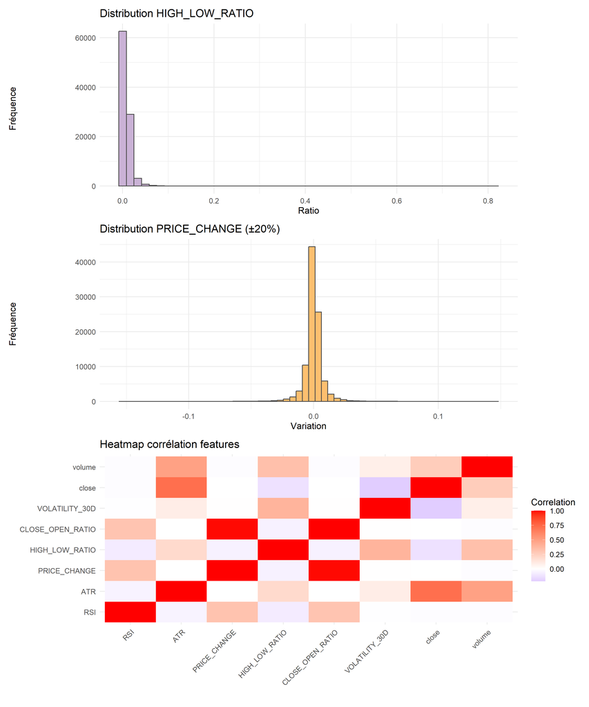

```r
plots <- list()

if ("HIGH_LOW_RATIO" %in% names(dt)) {
  dt_clean <- dt %>% filter(!is.na(HIGH_LOW_RATIO))
  plots$p1 <- ggplot(dt_clean, aes(x = HIGH_LOW_RATIO)) +
    geom_histogram(bins = 50, fill = "#CAB2D6", color = "grey30") +
    labs(title = "Distribution HIGH_LOW_RATIO", x = "Ratio", y = "Fréquence") +
    theme_minimal()
}

if ("PRICE_CHANGE" %in% names(dt)) {
  dt_clean <- dt %>% filter(!is.na(PRICE_CHANGE), abs(PRICE_CHANGE) < 0.2)
  plots$p2 <- ggplot(dt_clean, aes(x = PRICE_CHANGE)) +
    geom_histogram(bins = 60, fill = "#FDBF6F", color = "grey30") +
    labs(title = "Distribution PRICE_CHANGE (±20%)", x = "Variation", y = "Fréquence") +
    theme_minimal()
}

# Heatmap corrélation
numeric_cols <- intersect(names(dt), c("close","volume","ATR","RSI","VOLATILITY_30D","PRICE_CHANGE","HIGH_LOW_RATIO","CLOSE_OPEN_RATIO"))
if (length(numeric_cols) >= 2) {
  dt_cor <- dt %>% select(all_of(numeric_cols)) %>% na.omit()
  if (nrow(dt_cor) > 10) {
    cor_mat <- cor(dt_cor, use = "complete.obs")
    cor_tidy <- as.data.frame(as.table(cor_mat))
    names(cor_tidy) <- c("Var1","Var2","Correlation")

    plots$p3 <- ggplot(cor_tidy, aes(x = Var1, y = Var2, fill = Correlation)) +
      geom_tile() +
      scale_fill_gradient2(low = "blue", mid = "white", high = "red", midpoint = 0) +
      labs(title = "Heatmap corrélation features", x = "", y = "") +
      theme_minimal() +
      theme(axis.text.x = element_text(angle = 45, hjust = 1))
  }
}

if (length(plots) > 0) wrap_plots(plots, ncol = 1)
```

**Conclusion:** Le bruit domine, d’où l’importance du ML et du risk management.

# 🎬 Acte 7 — Synthèse finale

## Tableau récapitulatif

```r
summary_stats <- data.frame(
  Dimension = c("Prix", "Volatilité", "Volume", "Momentum"),
  Indicateur_clé = c("CLOSE", "VOLATILITY_30D", "VOLUME", "RSI"),
  Observation = c(
    "Croissance non linéaire avec phases d'explosion et de stagnation",
    "Fluctuante mais constante, le marché mûrit lentement",
    "Corrélé aux grands mouvements de prix, indicateur de crises/bull runs",
    "Le marché passe du temps en zones extrêmes (surachat/survente)"
  )
)

summary_stats %>% kable()
```

| Dimension | Indicateur_clé | Observation |
| --- | --- | --- |
| Prix | CLOSE | Croissance non linéaire avec phases d’explosion et de stagnation |
| Volatilité | VOLATILITY_30D | Fluctuante mais constante, le marché mûrit lentement |
| Volume | VOLUME | Corrélé aux grands mouvements de prix, indicateur de crises/bull runs |
| Momentum | RSI | Le marché passe du temps en zones extrêmes (surachat/survente) |

## Conclusion

Bitcoin est un marché **hautement non-stationnaire, émotionnel et volatil**, mais **riche en signaux exploitables**.

### Points clés

- **Prix** : croissance explosive avec phases de stagnation
- **Volatilité** : constante mais fluctuante, le marché mûrit lentement
- **Volume** : corrélé aux grands mouvements, indicateur de crises/bull runs
- **Momentum** : marché passe du temps en zones extrêmes (RSI)
- **Tendances** : courtes et violentes, alternance tendance/range
- **Ratios** : le bruit domine à l’échelle horaire → importance du ML et risk management

### Prochaines étapes

1. **Export** : `ggsave()` pour sauvegarder les visualisations
2. **Modélisation ML** : Random Forest, XGBoost, LSTM
3. **Backtesting** : stratégies de trading
4. **Séries temporelles** : ARIMA, Prophet
5. **Publication** : ce document Quarto peut être rendu en HTML/PDF/DOCX

## Informations techniques

**Stack utilisée :**

- `tidyverse` (dplyr, ggplot2, readr)
- `lubridate` (parsing dates)
- `TTR` (indicateurs techniques)
- `zoo` (rolling windows)
- `patchwork` (composition de plots)
- `DT` (tables interactives)
- `Quarto` (publication scientifique)

**Rendu du document :**

```bash
# HTML (par défaut)
quarto render bitcoin_storytelling.qmd

# PDF (nécessite LaTeX)
quarto render bitcoin_storytelling.qmd --to pdf

# DOCX (Word)
quarto render bitcoin_storytelling.qmd --to docx
```

*Document généré le 2026-01-07 avec Quarto & R.*